# 07 · Automatización de Excel con openpyxl (I)

## Automatización de Excel con openpyxl (I)

07 · EXCEL CON OPENPYXL · MODELO DE DATOS, AUTOMATIZACIÓN Y EFICIENCIA

Automatización de Excel  
con openpyxl (I)

**Fundamentos para automatizar y optimizar el trabajo con Excel**

Comprender los objetos, elegir operaciones y controlar su coste.

Datos de aula completamente ficticios.

## Automatización y optimización: dos objetivos

Automatizar significa convertir una operación repetible en un procedimiento ejecutable. Optimizar significa reducir su coste conservando el resultado requerido.

**Primero definimos qué resultado es correcto. Después elegimos cómo producirlo con menos trabajo y recursos.**

## Objetivos de aprendizaje

Comprender cómo openpyxl representa libros, hojas y celdas.

Elegir operaciones de lectura, escritura y formato según el trabajo.

Conservar tipos, referencias e información.

Razonar sobre tiempo, memoria y comprobación del resultado.

## Mapa conceptual de la sesión

| Núcleo | Pregunta que resuelve |
| --- | --- |
| Capacidad de la biblioteca | ¿Qué puede automatizar? |
| Modelo de objetos y tipos | ¿Qué estoy manipulando? |
| Lectura y transformación | ¿Qué datos necesito y cómo los recorro? |
| Escritura y presentación | ¿Cómo genero una entrega útil? |
| Eficiencia y fiabilidad | ¿Qué cuesta y cómo sé que es correcta? |

## 1 · Qué automatiza openpyxl

Lee y escribe archivos Office Open XML, especialmente `.xlsx`, desde Python.

Permite acceder a valores, fórmulas, estructura de hojas, estilos y otras propiedades admitidas. Trabaja sobre el archivo sin iniciar Excel para estas operaciones.

## Tres formas de trabajar con hojas de cálculo

| Enfoque | Objeto principal | Encaje habitual |
| --- | --- | --- |
| openpyxl | Libro, hoja y celda. | Leer o generar XLSX con estructura y formato. |
| Procesamiento tabular | Columnas y registros. | Transformaciones y agregaciones de datos. |
| Control de la aplicación | Instancia de Excel. | Operaciones que requieren la aplicación instalada. |

## Ámbito y límites de los formatos

Un archivo `.xlsx` es un formato de libro. Cambiar la extensión de un CSV no transforma su estructura.

El formato antiguo `.xls`, las macros y ciertos objetos complejos necesitan una estrategia específica.

## Qué hay dentro de un XLSX

| Parte del paquete ZIP | Responsabilidad |
| --- | --- |
| workbook.xml | Libro y relaciones de hojas. |
| worksheets/sheet*.xml | Datos y propiedades de hoja. |
| styles.xml | Fuentes, rellenos y formatos. |
| Relaciones y otras partes | Vínculos entre componentes y recursos. |

## Ciclo de vida de un libro

**Abrir o crear → seleccionar → leer o modificar → guardar → cerrar.**

Un objeto en memoria y un archivo persistente son estados diferentes. Modificar una celda no actualiza automáticamente el archivo de origen.

## 2 · Workbook, Worksheet y Cell

| Nivel | Acceso | Qué representa |
| --- | --- | --- |
| Workbook | wb | Conjunto de hojas y propiedades. |
| Worksheet | wb[“Datos”] | Espacio de filas y columnas. |
| Cell | ws[“C5”] | Valor, tipo, estilo y coordenada. |

## Crear una estructura en memoria

Workbook normal incluye una hoja inicial que podemos nombrar de manera explícita.

```python
from openpyxl import Workbook

wb = Workbook()
ws = wb.active
ws.title = "Datos"
wb.create_sheet("Resumen", 0)
print(wb.sheetnames)
```

## Seleccionar una hoja expresa una expectativa

Comprobar nombres permite detectar una entrada distinta de la prevista.

```python
if "Datos" not in wb.sheetnames:
    raise ValueError("Falta la hoja Datos")

ws = wb["Datos"]
print(ws.title, ws.max_column)
```

## Coordenadas y posición de los datos

`C5` identifica columna C y fila 5.

`ws.cell(row=5, column=3)` accede a la misma posición.

En la API de hoja, filas y columnas comienzan en **1**. En las tuplas Python, los índices comienzan en **0**.

## Objeto Cell frente a su valor

El objeto permite consultar coordenadas y metadata; value obtiene el contenido.

```python
ws["C5"] = 125
c = ws.cell(row=5, column=3)

print(c.value)
print(c.coordinate, c.row, c.column)
print(c.data_type, c.number_format)
```

## 3 · Valor, tipo y presentación

| Capa | Propiedad | Ejemplo |
| --- | --- | --- |
| Contenido Python | value | 1250 |
| Tipo de celda | data_type | n |
| Visualización | number_format | #,##0.00 |

El aspecto de una celda no demuestra que el dato tenga el tipo correcto.

## Tipos habituales al escribir

| Valor Python | Uso habitual | Precaución |
| --- | --- | --- |
| str | Nombres e identificadores. | Cadenas con = pueden ser fórmulas. |
| int o float | Cantidades. | Separar cantidad de unidad. |
| date o datetime | Fechas y horas. | Excel no conserva zona horaria. |
| bool | Condición lógica. | No confundirlo con un entero válido. |
| None | Ausencia de contenido. | No sustituirlo por cero sin criterio. |

## Identificadores con ceros iniciales

Un identificador representa identidad, aunque esté formado por cifras.

```python
ws["A2"] = "0001"
ws["A2"].number_format = "@"

ws["B2"] = 1
ws["B2"].number_format = "0000"
```

## Cero y ausencia tienen semánticas diferentes

No usar una comprobación de verdad para descartar valores de una columna numérica.

```python
ws["D2"] = 0
ws["D3"] = None

valor = ws["D2"].value
if valor is not None:
    print("Valor informado:", valor)
```

## Fechas tipadas y texto parecido a una fecha

Escribir un objeto de fecha conserva operaciones de calendario y una representación coherente.

```python
from datetime import date

ws["C2"] = date(2026, 10, 1)
ws["C2"].number_format = "dd/mm/yyyy"
ws["C3"] = "01/10/2026"
```

## La conversión de fechas necesita una regla

Una cadena como `01/02/2026` puede ser ambigua según el origen.

Define formato de entrada, política de errores y si admites hora. La conversión debe informar qué registros no puede interpretar.

## Apariencia y significado

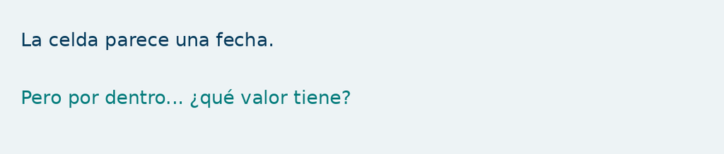

## Números, precisión y unidades

Un valor numérico debe almacenar la cantidad, no su etiqueta visual.

`1250.5` y `"1.250,50 €"` exigen tratamientos diferentes. Define moneda, unidad, redondeo y tolerancia de comparación.

## 4 · Leer un libro: elegir qué conservar

| Necesidad | Decisión de apertura |
| --- | --- |
| Modificar y guardar el libro | Modo normal. |
| Recorrer datos sin editar | Considerar read_only=True. |
| Inspeccionar expresiones | data_only=False. |
| Leer resultados guardados | data_only=True, comprobando su vigencia. |

## Lectura explícita con cierre de recursos

La lectura diferida mantiene un archivo abierto mientras se recorren los datos.

```python
from openpyxl import load_workbook

wb = load_workbook(entrada, read_only=True, data_only=False)
try:
    ws = wb["Datos"]
    for valores in ws.iter_rows(values_only=True):
        procesar(valores)
finally:
    wb.close()
```

## Filas, rangos y dimensiones

Un rango define el área que interesa, por ejemplo `A2:F200`.

`max_row` y `max_column` describen dimensiones de la hoja, no necesariamente el número de registros válidos.

## Recorrer solamente el área necesaria

Acotar columnas y filas evita inspeccionar partes irrelevantes del libro.

```python
for fila in ws.iter_rows(
    min_row=2, max_row=200,
    min_col=1, max_col=6, values_only=True
):
    if all(v is None for v in fila):
        continue
    procesar(fila)
```

## Celdas o valores: dos necesidades

| Recorrido | Entrega | Úsalo cuando necesitas |
| --- | --- | --- |
| iter_rows(values_only=True) | Tuplas de valores. | Transformar datos sin inspeccionar estilos. |
| iter_rows() | Objetos de celda. | Fórmulas, tipos o propiedades. |

values_only simplifica lo que recibes. El modo de apertura determina cómo se mantiene la hoja.

## Detectar fórmulas antes de perder contexto

Si la entrada exige valores, comprobar el tipo de celda conserva evidencia del incumplimiento.

```python
for fila in ws.iter_rows(min_row=2, max_col=6):
    if any(c.data_type in {"f", "e"} for c in fila):
        raise ValueError("Fórmula o error en datos de entrada")
    valores = tuple(c.value for c in fila)
```

## Calidad de entrada antes de transformar

Comprobar hoja esperada, cabeceras y tipo de cada campo reduce errores tardíos.

Distingue filas vacías, registros incompletos, identificadores repetidos y valores fuera de dominio.

## 5 · Separar lectura, transformación y escritura

**Lectura:** recuperar datos y validar su contrato.

**Transformación:** calcular y decidir con estructuras Python.

**Escritura:** representar los resultados en un libro.

## Agregar una vez durante el recorrido

Un resumen puede calcularse en la misma pasada que valida los registros.

```python
from collections import Counter

conteo = Counter()
for registro in registros:
    conteo[registro["estado"]] += 1

total = sum(conteo.values())
```

## Una lista completa tiene un coste

`list(iterador)` conserva todos sus elementos. Es útil para reutilizar datos, pero renuncia al procesamiento estrictamente secuencial.

Mantén solo lo necesario: acumuladores, claves o el conjunto completo si la operación lo requiere.

## 6 · Escribir por coordenada o por fila

| Estrategia | Encaja con | Límite que hay que recordar |
| --- | --- | --- |
| ws[“C5”] o ws.cell(…) | Plantillas y posiciones concretas. | La posición no identifica un registro. |
| ws.append(valores) | Generación de filas consecutivas. | Añade al final, no busca una clave. |

La elección depende de la estructura de salida.

## Ordenar campos al escribir una fila

El orden de columnas debe proceder de un esquema, no de una suposición sobre el diccionario.

```python
columnas = ("id", "fecha", "estado")
ws.append(columnas)

for registro in registros:
    ws.append([registro[campo] for campo in columnas])
```

## Controlar la interpretación de texto externo

Una cadena con signo igual puede adquirir semántica de fórmula si se asigna de manera ordinaria.

```python
c = ws.cell(row=2, column=6, value=texto_externo)
c.data_type = "s"
```

## Copiar datos no equivale a copiar un libro

Copiar valores, estilos, fórmulas y objetos son operaciones diferentes.

Una copia de hoja dentro del mismo libro tiene un alcance limitado. La preservación completa de una plantilla debe comprobarse.

## 7 · Estilos como representación del dato

| Elemento | Función |
| --- | --- |
| Font | Jerarquía y legibilidad. |
| PatternFill y Border | Agrupación visual. |
| Alignment | Ajuste y disposición del texto. |
| number_format | Presentación de cantidades y fechas. |

El dato conserva su significado aunque cambie su apariencia.

## Asignar estilos de manera explícita

Los componentes asignados se comparten y no se modifican directamente sobre la celda.

```python
from openpyxl.styles import Font, PatternFill

cabecera = Font(bold=True, color="FFFFFF")
fondo = PatternFill("solid", fgColor="003B5C")
for c in ws[1]:
    c.font = cabecera
    c.fill = fondo
```

## Variar una celda sin mutar el estilo compartido

Copiar un componente permite cambiar solo la propiedad requerida.

```python
from copy import copy

nueva_fuente = copy(ws["A2"].font)
nueva_fuente.bold = True
ws["A2"].font = nueva_fuente
```

## Formato numérico: contenido y visualización

| Código | Intención visual |
| --- | --- |
| #,##0 | Enteros con agrupación. |
| #,##0.00 | Dos decimales. |
| 0.0% | Proporción mostrada como porcentaje. |
| dd/mm/yyyy | Fecha de calendario. |

Para 25 %, el valor numérico habitual es **0,25**, no 25.

## Dimensiones y ajuste del contenido

El ancho de columna y la altura de fila condicionan la legibilidad. `wrap_text` permite varias líneas, pero no garantiza por sí solo la altura final.

Ajusta rangos relevantes y comprueba la entrega visualmente.

## Formato acotado a la zona de datos

Las operaciones de presentación también deben limitarse al área que se utiliza.

```python
from openpyxl.styles import Alignment

ws.column_dimensions["B"].width = 48
for fila in ws.iter_rows(min_row=2, max_row=200, max_col=6):
    for c in fila:
        c.alignment = Alignment(wrap_text=True, vertical="top")
```

## Filtros, paneles y celdas combinadas

**Filtro:** configura controles para explorar filas en la aplicación.

**Paneles:** mantienen cabeceras o claves visibles al desplazarse.

**Combinaciones:** reservadas para títulos, fuera de los registros.

## 8 · Fórmulas y motor de cálculo

Una fórmula es una expresión almacenada. Su resultado puede existir en una caché guardada por una aplicación de cálculo.

**openpyxl escribe fórmulas, pero no las evalúa.**

## Expresión y valor cacheado

La opción de lectura decide qué representación se recupera, no si se calcula.

```python
ws["B3"] = "=SUM(B1:B2)"

formulas = load_workbook(ruta, data_only=False)
valores = load_workbook(ruta, data_only=True)
```

## ¿Calcular en Python o en Excel?

| Necesidad | Criterio |
| --- | --- |
| Entrega de valores reproducibles | Calcular en Python y comprobarlos. |
| Modelo que debe reaccionar a entradas en Excel | Diseñar fórmulas y ensayar recálculo. |
| Preservar un modelo existente | Leer sus fórmulas y analizar lo que se conserva. |

## 9 · Un modelo de coste para decidir

$$T\approx T_{carga}+N\,C\,t_{celda}+T_{transformación}+T_{guardado}$$

$N$: filas recorridas. $C$: columnas consideradas. Los costes no dependen solo del número de registros.

## El tamaño del XLSX no determina la RAM

El archivo está comprimido. El libro en memoria contiene objetos y estructuras auxiliares.

La demanda cambia con el modo de apertura, los estilos, las cadenas y los datos que tu programa conserva.

## Guardar dentro de cada iteración repite trabajo

Si se añade una fila y se serializa todo el libro cada vez, se vuelven a escribir datos ya procesados.

Construir el resultado y guardar al final evita esa repetición cuando el flujo lo permite.

## Coste acumulado bajo un modelo simplificado

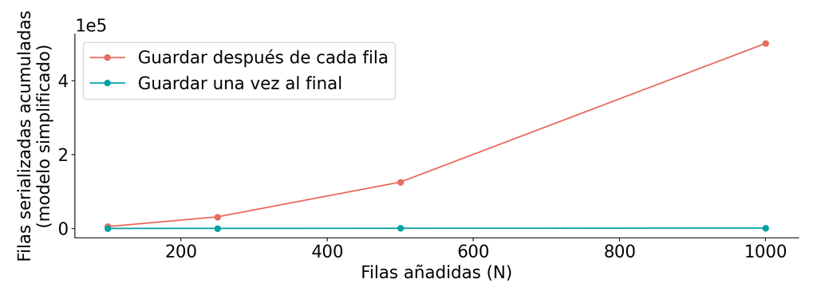

## Orden de crecimiento del trabajo repetido

$$\sum_{j=1}^{N}j=\frac{N(N+1)}{2}\quad\text{frente a}\quad N$$

Para 1.000 filas: **500.500 frente a 1.000 filas serializadas**, bajo estas hipótesis.

## Otras repeticiones que conviene detectar

Cargar el mismo libro para cada fila. Recorrer todas las columnas para usar una. Volver a calcular un resumen ya disponible. Construir estilos idénticos en cada celda.

Prioriza los costes grandes y las operaciones de disco.

## 10 · Modos de acceso y sus compromisos

| Modo | Ventaja principal | Renuncia |
| --- | --- | --- |
| Normal | Edición y acceso flexible. | Mayor estructura en memoria. |
| read_only | Recorrido secuencial con menor retención de celdas. | No editar la hoja. |
| write_only | Generar filas de forma secuencial. | No volver a modificar celdas arbitrarias. |

## Lectura read_only: qué cambia

La hoja se interpreta de forma diferida al recorrerla. Abrir rápido no significa haber leído todos los registros.

Mide carga **y recorrido**. Cierra el libro y evita convertir todo el flujo a una lista si no es necesario.

## Leer y agregar con memoria acotada por el cálculo

Un acumulador conserva el resultado del resumen, en lugar de todas las filas.

```python
wb = load_workbook(entrada, read_only=True, data_only=False)
try:
    conteo = Counter()
    for fila in wb["Datos"].iter_rows(min_row=2, values_only=True):
        conteo[fila[4]] += 1
finally:
    wb.close()
```

## Escritura write_only: planificar antes de emitir

Las filas se añaden secuencialmente. La hoja se crea de forma explícita y la estructura debe planificarse antes de escribir.

Configura opciones previas, como paneles, y guarda una sola vez.

## Generar un libro secuencial

Adecuado cuando no se necesita volver atrás para modificar el contenido.

```python
wb = Workbook(write_only=True)
ws = wb.create_sheet("Datos")
ws.freeze_panes = "A2"
ws.append(("id", "estado"))
for registro in registros:
    ws.append((registro["id"], registro["estado"]))
wb.save(salida)
```

## Elegir el modo con una pregunta concreta

¿Debo editar celdas existentes o conservar una plantilla? **Normal.**

¿Solo necesito extraer datos recorriendo filas? **Considerar read_only.**

¿Genero una tabla nueva de principio a fin? **Considerar write_only.**

## 11 · Medir una optimización con criterio

Define el mismo trabajo y el mismo resultado. Separa preparación, carga, recorrido y guardado. Repite en condiciones comparables.

Registra versiones, dimensiones, tipos de dato y modo de apertura.

## Medir tiempo de una fase completa

perf_counter mide duración transcurrida; no utilizar la fecha del sistema como cronómetro.

```python
from time import perf_counter

inicio = perf_counter()
resultado = leer_y_resumir(entrada)
segundos = perf_counter() - inicio
print(segundos)
```

## Qué significa medir memoria

El pico de memoria informa de cuánto necesita el proceso en su momento más exigente.

tracemalloc observa asignaciones rastreadas de Python; la memoria del proceso puede incluir otras reservas.

## 12 · Fiabilidad como parte de la eficiencia

Una ejecución que produce un resultado incorrecto añade corrección manual, repeticiones y pérdida de confianza.

Validación temprana, nombres de salida explícitos y comprobación al reabrir reducen trabajo de recuperación.

## Publicar una entrega tiene varias fases

Construir el libro en memoria. Escribir a un destino de preparación. Reabrir y contrastar. Publicar el nombre final.

La entrada original permanece separada de la entrega.

## Verificación de contenido y de uso

| Nivel | Ejemplo de evidencia |
| --- | --- |
| Estructura | Hojas y cabeceras esperadas. |
| Datos | IDs, tipos, filas y totales reconciliados. |
| Presentación | Anchos, formatos y textos visibles. |
| Comportamiento | Filtros o fórmulas ensayados en su motor. |

## Errores frecuentes y su causa

| Síntoma | Causa a investigar |
| --- | --- |
| ID sin ceros iniciales | Conversión numérica de un código. |
| Fecha que no se ordena como se espera | Texto con apariencia de fecha. |
| Lectura data_only devuelve None | Falta de caché de fórmula. |
| Consumo excesivo | Modo, rango o datos retenidos. |
| Tiempo de exportación crece mucho | Guardados o recorridos repetidos. |

## Síntesis de criterios de elección

El modelo de objetos explica **qué** manipulamos. Los tipos y el contrato explican **qué significa**. El modo y el algoritmo explican **qué cuesta**. La verificación explica **qué evidencia tenemos**.

## Aplicación breve · El observatorio

Los diez documentos del curso permiten comprobar estas ideas en un caso conocido.

Una fila representa una entrada física. Conservamos cuatro publicaciones, un duplicado, tres revisiones y dos conflictos.

## Del modelo de datos a las celdas

| Campo del ejemplo | Decisión teórica aplicada |
| --- | --- |
| entrada_id | Texto que conserva cuatro cifras. |
| fecha | date o ausencia documentada. |
| bytes | Entero no negativo. |
| estado y motivo | Categorías que se conservan como texto. |

## Una vista de seguimiento coherente

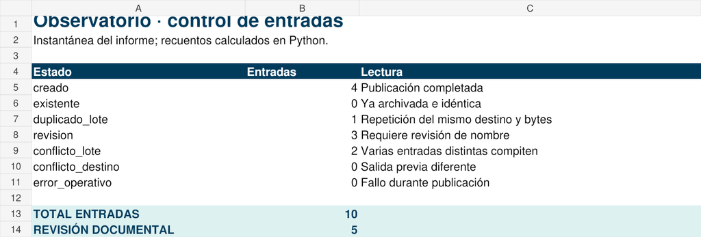

## Práctica complementaria y continuidad

El material práctico contiene doce ejercicios de objetos, tipos, lectura, formato y entrega verificada.

La siguiente sesión ampliará fórmulas, tablas, gráficos, validación de datos y formato condicional.

## Fuentes primarias · Conceptos de openpyxl

[Tutorial y modelo de objetos](https://openpyxl.readthedocs.io/en/stable/tutorial.html).

[Estilos](https://openpyxl.readthedocs.io/en/stable/styles.html) y [fórmulas](https://openpyxl.readthedocs.io/en/stable/simple_formulae.html).

[Modos optimizados](https://openpyxl.readthedocs.io/en/stable/optimized.html) y [rendimiento](https://openpyxl.readthedocs.io/en/stable/performance.html).

## Fuentes y material de consulta

[Python: datetime](https://docs.python.org/3.11/library/datetime.html), [collections](https://docs.python.org/3.11/library/collections.html) y [medición de tiempo](https://docs.python.org/3.11/library/time.html#time.perf_counter).

[Quarto: presentación autocontenida](https://quarto.org/docs/presentations/revealjs/presenting.html).

Menú lateral para consultar conceptos. **N** para notas docentes.

**Notas docentes · N para cerrar**